# Analise Segregação

Author

Pedro Henrique Vargas de Araujo

## 1. Introdução

Este relatório tem como objetivo avaliar a segregação de marcadores no dataset. A análise consiste em testar se os genótipos observados seguem a proporção esperada sob herança mendeliana. Na base, os homozigotos dominantes foram identificados como 0, os homozigotos recessivos como 2 e os heterozigotos como 1

O foco da análise está nos homozigotos (0 e 2), para ver se sguem a proporção de 1:1. (advinda da proporção 1:2:1 de Mendel)

## Desenvolvimento

### Hipótese Estatística

- **H0 (hipótese nula):** proporção de 0 e 2 é igual (1:1)
- **H1 (hipótese alternativa):** proporção diferente de 1:1

### Importação dos Dados

```r
library(tidyverse)
dados <- read.csv("C:/Users/ph408/Downloads/Z009.csv", header=FALSE, row.names=1)

### 4. Seleção das colunas

marcadores <- names(dados)[2:1138]

#verificação se os marcadores estão ok
length(marcadores)
```

```
[1] 1137
```

```r
head(marcadores)
```

```
[1] "V3" "V4" "V5" "V6" "V7" "V8"
```

### Analise dos marcadores

```r
analisa_chi <- function(vetor, nome_marcador){

  vetor <- suppressWarnings(as.numeric(as.character(vetor)))
  vetor <- vetor[!is.na(vetor)]

  n0 <- sum(vetor == 0)
  n2 <- sum(vetor == 2)

  n_hom <- n0 + n2

  if(n_hom == 0){
    return(tibble(
      marcador = nome_marcador,
      n0 = NA,
      n2 = NA,
      esperado = NA,
      qui_quadrado = NA,
      p_valor = NA,
      significativo = NA,
      interpretacao = NA
    ))
  }

  # valores esperados (1:1)
  esperado <- n_hom / 2

  # teste qui-quadrado
  teste <- chisq.test(c(n0, n2), p = c(0.5, 0.5), correct = FALSE)

  p_valor <- teste$p.value
  chi <- as.numeric(teste$statistic)

  significativo <- p_valor < 0.05

  interpretacao <- ifelse(significativo,
                         "Distorção de segregação",
                         "Segregação esperada")

  tibble(
    marcador = nome_marcador,
    n0 = n0,
    n2 = n2,
    esperado = esperado,
    qui_quadrado = round(chi, 3),
    p_valor = round(p_valor, 5),
    significativo = significativo,
    interpretacao = interpretacao
  )
}

# Aplicar a todos os marcadores
resultados_chi <- map_dfr(marcadores, ~ analisa_chi(dados[[.x]], .x))

# Visualizar
head(resultados_chi)
```

```
# A tibble: 6 × 8
  marcador    n0    n2 esperado qui_quadrado p_valor significativo interpretacao
  <chr>    <int> <int>    <dbl>        <dbl>   <dbl> <lgl>         <chr>
1 V3          76   100     88          3.27  0.0704  FALSE         Segregação e…
2 V4          91    90     90.5        0.006 0.941   FALSE         Segregação e…
3 V5         113    68     90.5       11.2   0.00082 TRUE          Distorção de…
4 V6          98    84     91          1.08  0.299   FALSE         Segregação e…
5 V7          66    82     74          1.73  0.188   FALSE         Segregação e…
6 V8          89    92     90.5        0.05  0.824   FALSE         Segregação e…
```

Dos 1106 marcadores avaliados, 171 apresentaram evidência de distorção de segregação ao nível de 5%. Portanto, o conjunto como um todo mostra um predomínio de marcadores compatíveis com a segregação 1:1

### Sampling

Agora, selecionaremos 5 marcadores aleatórios, usando como seed meu id usp

```r
set.seed(17765673)
marcadores_sel <- sample(marcadores, 5)
marcadores_sel
```

```
[1] "V1073" "V465"  "V721"  "V576"  "V490"
```

### Visualização

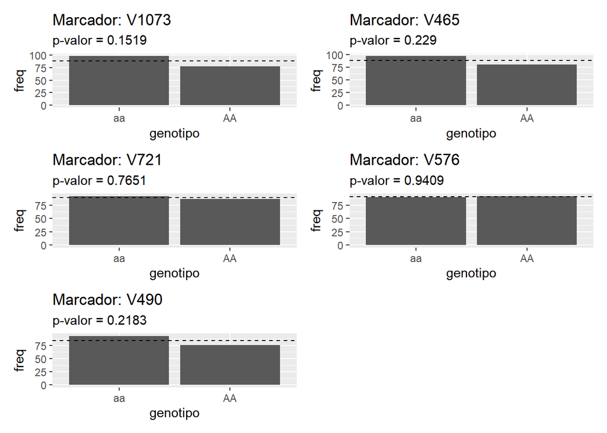

```r
library(ggplot2)

plots <- lapply(marcadores_sel, function(m) {

  vetor <- dados[[m]]
  vetor <- vetor[!is.na(vetor)]

  n0 <- sum(vetor == 0)
  n2 <- sum(vetor == 2)
  n_hom <- n0 + n2

  df <- tibble(
    genotipo = c("AA", "aa"),
    freq = c(n0, n2)
  )

  p_valor <- if (n_hom > 0) binom.test(n0, n_hom, p = 0.5)$p.value else NA

  ggplot(df, aes(x = genotipo, y = freq)) +
    geom_col() +
    geom_hline(yintercept = n_hom/2, linetype = "dashed") +
    labs(
      title = paste("Marcador:", m),
      subtitle = paste("p-valor =", round(p_valor, 4))
    )
})
library(patchwork)
wrap_plots(plots, ncol = 2)
```